[figure not shown]

# Скрипин Антон ФТ-360008

# Лабораторная работа - Классификация дерева решений

### Цели

«В этой лабораторной работе вы будете использовать модель классификатора дерева решений, чтобы определить, кто пережил катастрофу Титаника.

**Часть 1: Создать классификатор дерева решений **

**Part 2: Применить модель дерева принятия решений**

**Part 3: Оценка модели дерева принятия решений**

### История/Cценарий

В этой лабораторной работе вы создадите классификатор дерева решений, который будет работать с набором данных содержащим сведения о более чем 1300 пассажирах, которые были на борту пассажирского лайнера Титаник в его печально известном первом рейсе.

### Необходимые ресурсы

- 1 ПК с доступом в Интернет
- Библиотеки Python: `pandas`, `sklearn`, и `IPython.display`
- Дополнительное приложение: Graphviz
- Файлы данных: titanic-train.csv, titanic-test.csv, titanic_all.csv

## Часть 1: Создать классификатор дерева решений

В этой части лабораторной работы вы создадите классификатор дерева решений, который будет обучаться благодаря маркированному набору данных.

Набор данных содержит имена и демографические данные для каждого пассажира. Кроме того, включены детали поездки каждого пассажира. Из этих данных мы можем построить дерево решений, которое иллюстрирует факторы способствовавшие положительному или отрицательному исходу для пассажира рейса.

Наборы данных содержат следующие переменные:

| Переменная | Описание |
| --- | --- |
| 1. PassengerID | Уникальный идентификатор для каждого пассажира |
| 2. Survival | Выжил ли пассажир? (0 = Нет; 1 = Да) |
| 3. Pclass | Класс пассажирских билетов. (1 = Первый класс; 2 = Второй класс; 3 = Третий класс) |
| 4. Name | ФИО пассажира (фамилия, имя) |
| 5. Gender | Мужской или женский |
| 6. Age | Возраст в годах. В основном целые числа и числа с плавающей запятой для детей младше одного года. |
| 7. SibSp | Число братьев и сестер на борту. |
| 8. Parch | Число родителей или детей на борту. |
| 9. Ticket | Номер билета |
| 10. Fare | Сумма, уплаченная за проезд в британских фунтах 1970 года |
| 11. Cabin | Номер каюты |
| 12. Embarked | Порт высадки (C = Шербур; Q = Куинстаун; S = Саутгемптон) |

Учитывая приведенные выше данные, вопросы какого типа мы можем задать о факторах, способствовавших выживанию или гибели пассажиров в катастрофе «Титаника»?

*Какой пол, возраст?*

#### Шаг 1: Создайте кадр данных

##### a) Импортируйте pandas и файл csv

В первую очередь, импортируйте `pandas` и создайте кадр данных из набора данных для обучения, который хранится в файле titanic-train.csv. Используйте метод `pd.read_csv()`.

```python
#Ячейка для кода №1
#Импортируйте pandas
import pandas as pd

#создайте кадр данных pandas с именем "training" из файла titanic-train.csv
training = pd.read_csv(r"titanic-train.csv")
```

##### b) Проверьте импорт и просмотрите данные.

```python
#Ячейка для кода №2
#проверьте содержимое кадра данных для обучения с помощью метода info() библиотеки pandas.
training.info()
```

```
<class 'pandas.core.frame.DataFrame'>
RangeIndex: 915 entries, 0 to 914
Data columns (total 12 columns):
PassengerId    915 non-null int64
Survived       915 non-null int64
Pclass         915 non-null int64
Name           915 non-null object
Gender         915 non-null object
Age            738 non-null float64
SibSp          915 non-null int64
Parch          915 non-null int64
Ticket         915 non-null object
Fare           915 non-null float64
Cabin          202 non-null object
Embarked       914 non-null object
dtypes: float64(2), int64(5), object(5)
memory usage: 85.9+ KB
```

Есть ли отсутствующие значения в наборе данных?

у некоторый пассажиров отсутствует возраст, номер каюты и у одного пассажира - порт высадки

```python
#Ячейка для кода №3
training.head()
```

|  | PassengerId | Survived | Pclass | Name | Gender | Age | SibSp | Parch | Ticket | Fare | Cabin | Embarked |
| --- | --- | --- | --- | --- | --- | --- | --- | --- | --- | --- | --- | --- |
| 0 | 1 | 0 | 1 | Davidson, Mr. Thornton | male | 31.0 | 1 | 0 | F.C. 12750 | 52.0000 | B71 | S |
| 1 | 2 | 0 | 3 | Asim, Mr. Adola | male | 35.0 | 0 | 0 | SOTON/O.Q. 3101310 | 7.0500 | NaN | S |
| 2 | 3 | 0 | 3 | Nankoff, Mr. Minko | male | NaN | 0 | 0 | 349218 | 7.8958 | NaN | S |
| 3 | 4 | 0 | 1 | Thayer, Mr. John Borland | male | 49.0 | 1 | 1 | 17421 | 110.8833 | C68 | C |
| 4 | 5 | 0 | 3 | Strandberg, Miss. Ida Sofia | female | 22.0 | 0 | 0 | 7553 | 9.8375 | NaN | S |

#### Шаг 2: Подготовьте данные для модели дерева решений.

##### a) Замените строковые данные числовыми метками

Мы будем использовать scikit-learn для создания деревьев решений. Модель дерева решений, которую мы будем использовать, может обрабатывать только числовые данные. Значения для переменной Gender должны быть преобразованы в числовые представления. 0 будет использоваться для обозначения "мужской" и 1 будет обозначать "женский."

В этом коде lambda выражение используется с методом `apply()`. Lambda выражение представляет собой функцию, которая использует условную инструкцию для замены текстовых значений в столбцах соответствующим числовым значением. Оператор lambda может быть интерпретирован как "если параметр toLabel равен 'male', верни 0, если это значение является чем-то другим, верни 1." Метод `apply()` будет выполнять эту функцию для всех значений в столбце "Gender".

```python
#Ячейка для кода №4
training["Gender"] = training["Gender"].apply(lambda toLabel: 0 if toLabel == 'male' else 1)
```

##### b) Убедитесь, что переменная Gender изменилась.

В результате в наборе данных должны быть значения 0 или 1 для переменной Gender.

```python
#Ячейка для кода №5
#снова просмотрите первые несколько строк данных
training.head()
```

|  | PassengerId | Survived | Pclass | Name | Gender | Age | SibSp | Parch | Ticket | Fare | Cabin | Embarked |
| --- | --- | --- | --- | --- | --- | --- | --- | --- | --- | --- | --- | --- |
| 0 | 1 | 0 | 1 | Davidson, Mr. Thornton | 0 | 31.0 | 1 | 0 | F.C. 12750 | 52.0000 | B71 | S |
| 1 | 2 | 0 | 3 | Asim, Mr. Adola | 0 | 35.0 | 0 | 0 | SOTON/O.Q. 3101310 | 7.0500 | NaN | S |
| 2 | 3 | 0 | 3 | Nankoff, Mr. Minko | 0 | NaN | 0 | 0 | 349218 | 7.8958 | NaN | S |
| 3 | 4 | 0 | 1 | Thayer, Mr. John Borland | 0 | 49.0 | 1 | 1 | 17421 | 110.8833 | C68 | C |
| 4 | 5 | 0 | 3 | Strandberg, Miss. Ida Sofia | 1 | 22.0 | 0 | 0 | 7553 | 9.8375 | NaN | S |

##### c) Переменные со значением Address Missing в наборе данных

Вывод метода info() показал, что около 180 наблюдений не имеют значения возраста. Значения возраста важны для нашего анализа. Мы должны каким-то образом устранить эти недостающие значения. Хотя это и не идеально, мы можем заменить эти недостающие значения средним возрастом для всего набора данных.

Это делается с помощью метода `fillna()` для столбца "Age" в наборе данных. Метод `fillna()` изменит исходный кадр данных с помощью аргумента `inplace = True`.

```python
#Ячейка для кода №6
training["Age"].fillna(training["Age"].mean(), inplace=True)
```

##### d) Убедитесь, что значения были заменены.

```python
#Ячейка для кода №7
#убедитесь, что отсутствующие значения для переменной age были удалены.
training.info()
training.head()
```

```
<class 'pandas.core.frame.DataFrame'>
RangeIndex: 915 entries, 0 to 914
Data columns (total 12 columns):
PassengerId    915 non-null int64
Survived       915 non-null int64
Pclass         915 non-null int64
Name           915 non-null object
Gender         915 non-null int64
Age            915 non-null float64
SibSp          915 non-null int64
Parch          915 non-null int64
Ticket         915 non-null object
Fare           915 non-null float64
Cabin          202 non-null object
Embarked       914 non-null object
dtypes: float64(2), int64(6), object(4)
memory usage: 85.9+ KB
```

|  | PassengerId | Survived | Pclass | Name | Gender | Age | SibSp | Parch | Ticket | Fare | Cabin | Embarked |
| --- | --- | --- | --- | --- | --- | --- | --- | --- | --- | --- | --- | --- |
| 0 | 1 | 0 | 1 | Davidson, Mr. Thornton | 0 | 31.000000 | 1 | 0 | F.C. 12750 | 52.0000 | B71 | S |
| 1 | 2 | 0 | 3 | Asim, Mr. Adola | 0 | 35.000000 | 0 | 0 | SOTON/O.Q. 3101310 | 7.0500 | NaN | S |
| 2 | 3 | 0 | 3 | Nankoff, Mr. Minko | 0 | 29.970867 | 0 | 0 | 349218 | 7.8958 | NaN | S |
| 3 | 4 | 0 | 1 | Thayer, Mr. John Borland | 0 | 49.000000 | 1 | 1 | 17421 | 110.8833 | C68 | C |
| 4 | 5 | 0 | 3 | Strandberg, Miss. Ida Sofia | 1 | 22.000000 | 0 | 0 | 7553 | 9.8375 | NaN | S |

Какой возраст использовался для замены отсутствующих значений?

```python
training["Age"].mean()
```

```
29.970867208672033
```

Использовался для замены следующий возраст 29.970867208672033

#### Шаг 3: Обучение и оценка модели дерева решений.

##### a) Создайте массив с переменной, которая будет являться целью для модели.

Целью модели является классификация пассажиров на оставшихся в живых или нет. В процессе обучения модель будет учиться определять, какие значения входных переменных, скорее всего, указывают на принадлежность пассажира к жертвам или выжившим, а затем использовать эту информацию для классификации пассажиров из уникального набора тестовых данных.

```python
#Ячейка для кода №8
#создать массив для выходных значений
y_target = training["Survived"].values
```

##### b) Создайте массив значений, которые будут направленны на вход модели.

Только некоторые характеристики данных полезны для создания дерева классификаторов. Мы создадим список столбцов из данных, которые мы хотим, чтобы классификатор использовал в качестве входных переменных, а затем создадим массив, используя названия столбцов из этой переменной. Переменная `X_input` содержит значения для всех характеристик, которые будут использоваться моделью для классификации. После обучения модели мы будем использовать эту переменную, чтобы присвоить эти метки набору тестовых данных.

```python
#Ячейка для кода №9
columns = ["Fare", "Pclass", "Gender", "Age", "SibSp"]
#создайте переменную для хранения характеристик, которые будет использовать классификатор
X_input = training[list(columns)].values
```

##### c) Создайте обученную модель.

Импортируйте модуль дерева решений из библиотеки машинного обучения `sklearn`. Создайте объект-классификатор `clf_train`. Затем используйте метод `fit()` объекта классификатора, с помощью переменных X_input и y_target в качестве параметров, для обучения модели.

```python
#Ячейка для кода №10
#импортируйте модуль дерева из библиотеки sklearn
from sklearn import tree

#создайте clf_train как объект классификатора дерева решений
clf_train = tree.DecisionTreeClassifier(criterion="entropy", max_depth=3)

#обучите модель с помощью метода fit().
#Отправьте в метод входную переменную X_input и выходную переменную y_target
clf_train = clf_train.fit(X_input, y_target)
```

##### d) Оцените модель

Используйте метод `score()` объекта дерева решений, чтобы отобразить в процентах точность присвоений, сделанных классификатором. В качестве аргументов он принимает входные и выходные переменные.

```python
#Ячейка для кода №11
clf_train.score(X_input,y_target)
```

```
0.8163934426229508
```

Эта оценка показывает, что классификации, сделанные моделью, должны быть правильными примерно в 82% случаев.

#### Шаг 6: Визуализируйте дерево

##### a) Создайте промежуточный файл для хранения выходных данных

Импортируйте модуль `sklearn.externals.six StringIO`, который используется для вывода характеристик дерева решений в файл. Мы создадим точечный файл Graphviz, который позволит нам экспортировать результаты классификатора в формат, который может быть представлен графически.

```python
#Ячейка для кода №12
from sklearn.externals.six import StringIO
with open(r"titanic.dot", 'w') as f:
    f = tree.export_graphviz(clf_train, out_file=f, feature_names=columns)
```

##### b) Установите Graphviz

Чтобы визуализировать дерево решений необходимо установить Graphviz. В процессе установки требуется ответить на запрос от операционной системы поэтому это не может быть выполнено из ячейки для кода в данном блокноте. Используйте команду `apt-get install graphviz` в командной строке терминала для установки этого программного обеспечения.

##### c) Отобразите графически промежуточный файл

Точечный файл, который был создан выше, может быть преобразован в .png-файл с графическим точечным рендером. Это команда оболочки, поэтому используйте `!` перед тем, как запустить его из этого блокнота. Новый файл с именем titanic.png должен появиться в каталоге с этим блокнотом.

```python
#Ячейка для кода №13
#запустите команду dot программы Graphviz для преобразования файла с расширением .dot в файл с расширением .png
!dot -Tpng ./Files_to_work/titanic.dot -o ./Files_to_work/titanic.png
```

##### d) Отобразите изображение

Теперь мы импортируем модуль `Image` из библиотеки `IPython.display`, что позволит нам открыть и отобразить внешний графический файл на странице блокнота. Функция `Image` используется для отображения файла с помощью .png-имени файла в качестве аргумента.

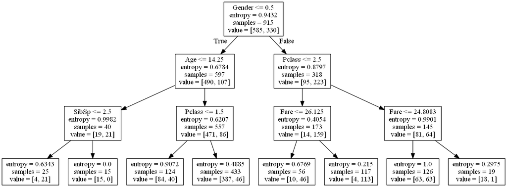

```python
#Ячейка для кода №14
#импортируйте модуль Image из библиотеки Ipython.display
from IPython.display import Image

#отобразите графически дерево решений
Image(r"titanic.png")
```

##### e) Интерпретируем дерево

Энтропия - это мера шума в решении. Шум можно рассматривать как неопределенность. Например, в узлах, в которых решение приводит к равным значениям в массиве значений выживаемости, энтропия имеет наивысшую возможную величину, равную 1.0. Это означает, что модель не смогла окончательно сделать классификационное решение на основе входных переменных. Для значений с очень низкой энтропией решение было гораздо более четким, а разница в числе выживших и жертв намного выше.

Что характеризует группу, в которой больше всего число смертей? В какой группе больше всего выживших?

в группу в которой больше всего смертей входят мужчины 2го и 3го класса

в группу в которой меньше всего смертей входят женщны 2го и 1го класса

## Часть 2: Применение модели дерева решений

В этой части лабораторной работы мы будем использовать результаты изученной модели дерева решений для маркировки немаркированного набора данных пассажиров Титаника. Дерево решений оценивает характеристики каждого наблюдения и маркирует наблюдение как выживший (метка = 1) или умер (метка = 0).

#### Шаг 1: Импорт и подготовка данных

На этом этапе вы будете импортировать и готовить данные для анализа.

##### a) Импортируйте данные.

Назовите кадр данных "testing" и импортируйте файл titanic-test.csv.

```python
#Ячейка для кода №15
#импортируйте файл в кадр данных 'testing'.
testing = pd.read_csv(r"titanic-test.csv")
```

Сколько записей в наборе данных?

393 записи

У каких важных переменных отсутствуют значения и сколько их не хватает?

Возраст - 86 значений

##### b) Используйте lambda выражение, чтобы заменить "male" и "female" значения на 0 для мужчин и 1 для женщин.

```python
#Ячейка для кода №16
testing["Gender"] = testing["Gender"].apply(lambda toLabel: 0 if toLabel == 'male' else 1)
```

##### c) Замените отсутствующие значения age средним возрастом.

```python
#Ячейка для кода №17
#Используйте метод fillna на столбце "Age" тестируемого кадра данных
#для замены отсутствующих значений средним значением возраста.
testing["Age"].fillna(testing["Age"].mean(), inplace=True)
```

##### d) Убедитесь, что значения были заменены.

Убедитесь, что пропущенные значения заполнены и что метки Gender 0 и 1.

```python
#Ячейка для кода №18
testing.info()
testing.head()
```

```
<class 'pandas.core.frame.DataFrame'>
RangeIndex: 393 entries, 0 to 392
Data columns (total 12 columns):
PassengerId    393 non-null int64
Survived       393 non-null int64
Pclass         393 non-null int64
Name           393 non-null object
Gender         393 non-null int64
Age            393 non-null float64
SibSp          393 non-null int64
Parch          393 non-null int64
Ticket         393 non-null object
Fare           393 non-null float64
Cabin          93 non-null object
Embarked       392 non-null object
dtypes: float64(2), int64(6), object(4)
memory usage: 36.9+ KB
```

|  | PassengerId | Survived | Pclass | Name | Gender | Age | SibSp | Parch | Ticket | Fare | Cabin | Embarked |
| --- | --- | --- | --- | --- | --- | --- | --- | --- | --- | --- | --- | --- |
| 0 | 916 | 0 | 2 | Coleridge, Mr. Reginald Charles | 0 | 29.0 | 0 | 0 | W./C. 14263 | 10.50 | NaN | S |
| 1 | 917 | 1 | 1 | Spedden, Mrs. Frederic Oakley (Margaretta Corn... | 1 | 40.0 | 1 | 1 | 16966 | 134.50 | E34 | C |
| 2 | 918 | 0 | 3 | Windelov, Mr. Einar | 0 | 21.0 | 0 | 0 | SOTON/OQ 3101317 | 7.25 | NaN | S |
| 3 | 919 | 1 | 1 | Minahan, Miss. Daisy E | 1 | 33.0 | 1 | 0 | 19928 | 90.00 | C78 | Q |
| 4 | 920 | 1 | 3 | Wilkes, Mrs. James (Ellen Needs) | 1 | 47.0 | 1 | 0 | 363272 | 7.00 | NaN | S |

#### Шаг 2: Промаркируйте тестируемый набор данных

На этом этапе вы примените изученную модель к тестируемому набору данных.

##### a) Создайте массив входных переменных из тестируемого набора данных.

```python
#Ячейка для кода №19
#создайте переменную X_input для хранения характеристик, которые будет использовать классификатор
X_input = testing[list(columns)].values
```

##### b) Примените модель к тестируемому набору данных.

Используйте метод `predict()` объекта `clf_train`, который был обучен помечать наблюдения в тестируемом наборе данных с наиболее вероятной классификацией выживаемости. В качестве параметра для этого метода используйте массив входных переменных из тестируемого набора данных.

```python
#Ячейка для кода №20
#примените модель к тестируемым данным и сохранить результат в кадре данных pandas.
#Используйте X_input в качестве аргумента для метода predict() объекта классификатора clf_train

target_labels = clf_train.predict(X_input)

#преобразуйте выходной массив в кадр данных pandas используя метод pd.DataFrame()
target_labels = pd.DataFrame({'Est_Survival':target_labels, 'Name':testing['Name']})

#отобразите первые несколько строк набора данных
target_labels.head()
```

|  | Est_Survival | Name |
| --- | --- | --- |
| 0 | 0 | Coleridge, Mr. Reginald Charles |
| 1 | 1 | Spedden, Mrs. Frederic Oakley (Margaretta Corn... |
| 2 | 0 | Windelov, Mr. Einar |
| 3 | 1 | Minahan, Miss. Daisy E |
| 4 | 0 | Wilkes, Mrs. James (Ellen Needs) |

##### c) Оцените точность предполагаемых меток

```python
#Ячейка для кода №21
#импортируйте библиотеку numpy как np
import pandas as pd
import numpy as np
# Загрузите данные для всех пассажиров в переменную all_data
all_data = pd.read_csv(r"titanic_all.csv")
# Для слияния используйте поле Name в качестве ключа, чтобы выбрать только строки из двух наборов данных, которые относятся к одному и тому же пассажиру
testing_results = pd.merge(target_labels, all_data[['Name','Survived']], on=['Name'])

# Вычислите точность как отношение совпадающих наблюдений к общему числу наблюдений. Сохраните её в переменной acc.
acc = np.sum(testing_results['Est_Survival'] == testing_results['Survived']) / float(len(testing_results))
# Выведите результат
acc
```

```
0.7588832487309645
```

## Часть 3: Оценка модели дерева решений

Библиотека `sklearn` включает в себя модуль, который может использоваться для оценки точности модели дерева решений. Метод `train_test_split()` разделяет наблюдения в целом по набору данных на два случайно выбранных массива. После подгонки модели к данным для обучения, можно произвести оценку обученной модели, а точность предсказания сравнить как для учебных, так и для тестовых наборов данных. Желательно, чтобы обе оценки были близкими, но точность для тестового набора данных обычно ниже, чем для набора данных для обучения.

##### Шаг 1. Импортируйте данные

На этот раз мы будем импортировать данные из файла `csv`, но мы укажем столбцы, которые мы хотим отобразить в кадре данных. Мы сделаем это, передав похожий на массив список имен столбцов в метод `read_csv()` параметром `usecols`. Используйте следующие столбцы: 'Survived', 'Fare', 'Pclass', 'Gender', 'Age', и 'SibSP'. Каждый из них должен быть в кавычках, а список должен быть выделен квадратными скобками. Назовите этот кадр данных `all_data`.

```python
#Ячейка для кода №22
#импортируйте файл titanic_all.csv в кадр данных с названием all_data. Укажите список столбцов для импорта.
all_data = pd.read_csv(r"titanic_all.csv", usecols=['Survived','Pclass','Gender','Age','SibSp','Fare'])
#Просмотрите info по новому кадру данных
all_data.info()
```

```
<class 'pandas.core.frame.DataFrame'>
RangeIndex: 1308 entries, 0 to 1307
Data columns (total 6 columns):
Survived    1308 non-null int64
Pclass      1308 non-null int64
Gender      1308 non-null object
Age         1045 non-null float64
SibSp       1308 non-null int64
Fare        1308 non-null float64
dtypes: float64(2), int64(3), object(1)
memory usage: 61.4+ KB
```

Сколько записей в наборе данных?

1308

У каких важных переменных отсутствуют значения и сколько их не хватает?

Возраст - 263 значения

#### Шаг 2: Подготовьте данные.

##### a) Удалите "male" и "female" строки и замените их на 0 и 1 соответственно.

```python
#Ячейка для кода №23
all_data["Gender"] = all_data["Gender"].apply(lambda toLabel: 0 if toLabel == 'male' else 1)
```

##### c) Замените отсутствующие значения age на средний возраст всех членов набора данных.

```python
#Ячейка для кода №24
all_data["Age"].fillna(all_data["Age"].mean(), inplace=True)
#отобразите первые несколько строк набора данных
all_data.head()
```

|  | Survived | Pclass | Gender | Age | SibSp | Fare |
| --- | --- | --- | --- | --- | --- | --- |
| 0 | 1 | 1 | 1 | 29.0000 | 0 | 211.3375 |
| 1 | 1 | 1 | 0 | 0.9167 | 1 | 151.5500 |
| 2 | 0 | 1 | 1 | 2.0000 | 1 | 151.5500 |
| 3 | 0 | 1 | 0 | 30.0000 | 1 | 151.5500 |
| 4 | 0 | 1 | 1 | 25.0000 | 1 | 151.5500 |

#### Шаг 2. Создайте входные и выходные переменные для данных обучения и тестирования

Библиотека `sklearn` включает в себя модули, которые помогают с выбором модели. Мы будем импортировать из `sklearn.model_selection` метода `train_test_split()`. Этот метод автоматически разбивает весь набор данных, возвращая в общей сложности четыре массива numpy, два для характеристик (тестирование и проверка) и два для меток (тестирование и проверка). Один параметр метода определяет долю наблюдений, используемых для тестирования и обучения. Другой параметр указывает начальное значение, которое будет использоваться для случайного назначения наблюдения на тестирование или обучение. Это используется для того, чтобы другой пользователь мог повторить вашу работу, получая те же самые назначения наблюдений наборам данных. Синтаксис метода:

```train_test_split(input_X, target_y, test_size=0.4, random_state=0)```

40% данных будут использоваться для тестирования. Случайное начальное значение устанавливается равным 0.

Метод возвращает четыре значения. Они возвращаются в следующем порядке: входные переменные для данных обучения, входные переменные для тестируемых данных, выходные переменные для данных обучения и выходные переменные для тестируемых данных.

##### a) Обозначьте входные переменные и выходные переменные и создайте массивы.

```python
#Ячейка для кода №25
#Импортируйте train_test_split() из библиотеки sklearn.model_selection

from sklearn.cross_validation import train_test_split

#создайте входные и выходные переменные назвав их буквами X и y. Повторно используйте переменную столбцов.
X = all_data[list(columns)].values
y = all_data["Survived"].values

#сгенерируйте четыре массива данных тестирования и обучения с помощью метода train_test_split()
X_train,X_test,y_train,y_test=train_test_split(X, y, test_size=0.40, random_state=0)
```

##### b) Обучите модель и подгоните ее к тестируемым данным.

Теперь снова можно использовать модель. Модель будет обучаться с использованием только учебных данных, выбранных функцией `train_test_split`.

```python
#Ячейка для кода №26
#создайте объект дерева решений обучения
clf_train = tree.DecisionTreeClassifier(criterion="entropy", max_depth=3)

#подгоните модель обучения с использованием входных и выходных переменных
clf_train = clf_train.fit(X_train, y_train)
```

##### c) Сравните модели, оценив каждую из них.

Использовать метод score() для каждого дерева решений для генерации оценок.

```python
#Ячейка для кода №27
#оцените модель на двух наборах данных и сохраните оценки в переменных. Преобразуйте оценки в строки с помощью str()
train_score = str(clf_train.score(X_train,y_train))
test_score = str(clf_train.score(X_test,y_test))

#выведите значения в тестовой строке
print('Training score = '+ train_score+' Testing score = '+test_score)
```

```
Training score = 0.8201530612244898 Testing score = 0.8053435114503816
```

Теперь мы сравнили оценки для обученной модели как по тестовым, так и по проверенным данным. Как и ожидалось, оценка точности для тестовых данных близка, но ниже, чем оценка для данных обучения. Это связано с тем, что, как правило, модель имеет тенденцию к переобучению на данных для обучения, поэтому оценка теста является лучшей оценкой того, как модель будет себя вести за пределами данных для обучения.

## Часть 4 Для дальнейшего изучения (необязательно)

Если у вас есть время и вы заинтересованы, вы можете попробовать следующее и посмотреть, как это влияет на дерево решений.

#### 1. Удалите наблюдения с отсутствующими значениями Age.

Использование среднего значения для замены отсутствующих значений возраста может повлиять на точность модели. Одним из подходов к этому может быть удаление всех наблюдений с отсутствующими возрастными значениями. Хотя это уменьшит размер набора учебных данных, это может повысить точность.

#### 2. Удалите входные переменные.

Еще одна проблема с этим типом анализа - это определение того, какие входные переменные или характеристики важны для точности классификатора. Один из способов сделать это - попробовать запустить классификатор с различными наборами входных переменных, отредактировав список переменных, которые соответствуют модели.

© 2017 Cisco and/or its affiliates. All rights reserved. This document is Cisco Public.